# Demonstrating Some Survey Data Functions

Fraser Hay

Last Updated: 12/15/2022

These functions are basically all designed to deal with categorical data, mainly because we typically deal with nominal/ordinal data from Qualtrics.

# 1 Data

For some of these examples I’ll be using the `mpg` dataset.

| manufacturer | model | displ | year | cyl | trans | drv | cty | hwy | fl | class |
| --- | --- | --- | --- | --- | --- | --- | --- | --- | --- | --- |
| audi | a4 | 1.8 | 1999 | 4 | auto(l5) | f | 18 | 29 | p | compact |
| audi | a4 | 1.8 | 1999 | 4 | manual(m5) | f | 21 | 29 | p | compact |
| audi | a4 | 2.0 | 2008 | 4 | manual(m6) | f | 20 | 31 | p | compact |
| audi | a4 | 2.0 | 2008 | 4 | auto(av) | f | 21 | 30 | p | compact |
| audi | a4 | 2.8 | 1999 | 6 | auto(l5) | f | 16 | 26 | p | compact |
| audi | a4 | 2.8 | 1999 | 6 | manual(m5) | f | 18 | 26 | p | compact |
| audi | a4 | 3.1 | 2008 | 6 | auto(av) | f | 18 | 27 | p | compact |
| audi | a4 quattro | 1.8 | 1999 | 4 | manual(m5) | 4 | 18 | 26 | p | compact |
| audi | a4 quattro | 1.8 | 1999 | 4 | auto(l5) | 4 | 16 | 25 | p | compact |
| audi | a4 quattro | 2.0 | 2008 | 4 | manual(m6) | 4 | 20 | 28 | p | compact |

[output cut: 224 more lines]

# 2 Frequency Table, Weighted

`ftw()` is a frequency table that takes weights into account, if specified.

```r
x = ftw(data, "manufacturer")
# Note: because no weight variable is specified, weights for all observations are set to 1.
x
```

| resp | count | pct |
| --- | --- | --- |
| dodge | 37 | 0.15811966 |
| toyota | 34 | 0.14529915 |
| volkswagen | 27 | 0.11538462 |
| ford | 25 | 0.10683761 |
| chevrolet | 19 | 0.08119658 |
| audi | 18 | 0.07692308 |
| hyundai | 14 | 0.05982906 |
| subaru | 14 | 0.05982906 |
| nissan | 13 | 0.05555556 |
| honda | 9 | 0.03846154 |

[output cut: 5 more lines]

It appears that **15.8%** of the observations in the `mpg` dataset relate to **dodge** cars.

# 3 Frequency Graph - Simple

`frq_g_simple` is for quick and simple graphs based on the output of `ftw()`.

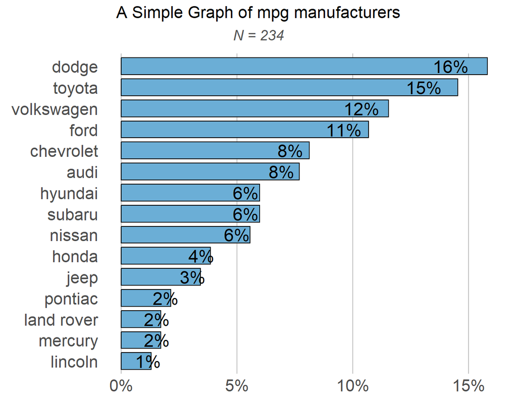

```r
frq_g_simple(x, "A Simple Graph of mpg manufacturers")
```

`frq_g_simple()` follows what is probably a familiar trend among users learning R: we came up with a ggplot config/aesthetic that we liked and kept using it over and over by making parameterizing a few key aspects and making it into a function.

# 4 Crosstabulation

I don’t know about you, but crosstabulations are basically our bread and butter - we employ them on virtually every question we report on. Mostly this is because we know some groups of students (eg. international students) tend to differ from their (domestic) counterparts.

But back to the data at-hand, about cars. `ct()` is what makes this happen - provide two variables and it’ll see how they intersect. It of course also allows you to specify a weighting variable, if needed.

```r
ct(data, year, class)
```

| year | suv | compact | midsize | subcompact | pickup | minivan | 2seater |
| --- | --- | --- | --- | --- | --- | --- | --- |
| Overall | 62 | 47 | 41 | 35 | 33 | 11 | 5 |
| 1999 (N = 117) | 29 | 25 | 20 | 19 | 16 | 6 | 2 |
| 2008 (N = 117) | 33 | 22 | 21 | 16 | 17 | 5 | 3 |

But what *percentage* of our data was that, you ask? You have two choices to get row percents.

## Within the `ct()` call (pct parameter)

```r
# One is in the ct() call.
t = ct(data, "year", "class", pct = TRUE)
t
```

| year | suv | compact | midsize | subcompact | pickup | minivan | 2seater |
| --- | --- | --- | --- | --- | --- | --- | --- |
| Overall | 0.2649573 | 0.2008547 | 0.1752137 | 0.1495726 | 0.1410256 | 0.04700855 | 0.02136752 |
| 1999 (N = 117) | 0.2478632 | 0.2136752 | 0.1709402 | 0.1623932 | 0.1367521 | 0.05128205 | 0.01709402 |
| 2008 (N = 117) | 0.2820513 | 0.1880342 | 0.1794872 | 0.1367521 | 0.1452991 | 0.04273504 | 0.02564103 |

28.2% of the 2008 sample were SUVs.

## Using `row_percents()`

```r
# Or you can call row_percents() on the ct() base frequency output. It assumes everything but the first column is supposed to be switched to row percentages.
t = row_percents( ct(data, "year", "class") )
t
```

| year | suv | compact | midsize | subcompact | pickup | minivan | 2seater |
| --- | --- | --- | --- | --- | --- | --- | --- |
| Overall | 0.2649573 | 0.2008547 | 0.1752137 | 0.1495726 | 0.1410256 | 0.04700855 | 0.02136752 |
| 1999 (N = 117) | 0.2478632 | 0.2136752 | 0.1709402 | 0.1623932 | 0.1367521 | 0.05128205 | 0.01709402 |
| 2008 (N = 117) | 0.2820513 | 0.1880342 | 0.1794872 | 0.1367521 | 0.1452991 | 0.04273504 | 0.02564103 |

28.2% of the 2008 sample were SUVs.

# 5 Crosstabulation: Rendering

Crosstabs are far more interesting in our “patented” `ctable()` (`DT::datatable`) rendering, since then you can see chi-square colouring, as we like:

```r
x = ct(data, "year", "cyl") # Let's look at year models by cylinder count.
ctable(x)
```

| year | 4 | 6 | 8 | 5 | count | 4_chi | 6_chi | 8_chi | 5_chi |
| --- | --- | --- | --- | --- | --- | --- | --- | --- | --- |
| Overall | 0.346153846153846 | 0.337606837606838 | 0.299145299145299 | 0.0170940170940171 | 0 | 10 | 10 | 10 | 10 |
| 1999 (N = 117) | 0.384615384615385 | 0.384615384615385 | 0.230769230769231 |  | 117 | 0 | 0 | -1 | 0 |
| 2008 (N = 117) | 0.307692307692308 | 0.290598290598291 | 0.367521367521368 | 0.0341880341880342 | 117 | 0 | 0 | 1 | 0 |

Looks like 8-cylinders were more popular in 2008 than would be expected, based on chi-square. *Wow. Such amaze.*

# 6 Crosstabulation: Tabset

One last thing to demonstrate is the `ct_tabset_dt()` function. As I mentioned, we do a lot of these crosstabs. So many that we like to loop through our key demos and show the distribution of the responses based on them. `ct_tabset_dt()` is designed to save me a lot of copy-pasting-with-slight-tweaks. You tell it how to generate a single crosstab (for a `ctable()` rendering), and it repeats it for all of your demos, with each product on its own tab. (Note, this code chunk is marked `{.tabset}`, and the message that appears before (/ after) the function call is built-in for reference.)

```r
# Just need to do some setup here.
Demos = c("cyl", "class", "drv") # The variables I want to crosstabulate by
Tabs = c("By Cylinder Count", "By Car Class", "By Drivetrain") # The names of the tabs
Params = c("Col1Name = 'Cylinders', chi2 = FALSE", "Col1Name = 'Car Class', chi2 = FALSE", "Col1Name = 'Drivetrain Type', chi2 = FALSE") # Parameters for each ctable() call, if applicable.

ct_tabset_dt("ct(data,x,'year')",Demos, Tabs, Params, HeadingLvl = 2)

# The above command spits out a reminder message:
# --- To preview the output, paste and run the following:
# ct.dt.out[['dt']]
# --- Include knit command *in-text* below for rendering (remember to end the tabset):
# `r paste(knit(text = ct.dt.out[['knit_code']]), collapse = '\n')`
```

## By Cylinder Count

```r
ct.dt.out[['dt']][[1]]
```

| Cylinders | 2008 | 1999 | count | V1 | V2 |
| --- | --- | --- | --- | --- | --- |
| Overall | 0.5 | 0.5 | 0 | 10 | 10 |
| 4 (N = 81) | 0.444444444444444 | 0.555555555555556 | 81 | 9 | 9 |
| 6 (N = 79) | 0.430379746835443 | 0.569620253164557 | 79 | 9 | 9 |
| 8 (N = 70) | 0.614285714285714 | 0.385714285714286 | 70 | 9 | 9 |
| 5 (N = 4) | 1 |  | 4 | 9 | 9 |

## By Car Class

```r
ct.dt.out[['dt']][[2]]
```

| Car Class | 2008 | 1999 | count | V1 | V2 |
| --- | --- | --- | --- | --- | --- |
| Overall | 0.5 | 0.5 | 0 | 10 | 10 |
| 2seater (N = 5) | 0.6 | 0.4 | 5 | 9 | 9 |
| compact (N = 47) | 0.468085106382979 | 0.531914893617021 | 47 | 9 | 9 |
| midsize (N = 41) | 0.51219512195122 | 0.48780487804878 | 41 | 9 | 9 |
| minivan (N = 11) | 0.454545454545455 | 0.545454545454545 | 11 | 9 | 9 |
| pickup (N = 33) | 0.515151515151515 | 0.484848484848485 | 33 | 9 | 9 |
| subcompact (N = 35) | 0.457142857142857 | 0.542857142857143 | 35 | 9 | 9 |
| suv (N = 62) | 0.532258064516129 | 0.467741935483871 | 62 | 9 | 9 |

## By Drivetrain

```r
ct.dt.out[['dt']][[3]]
```

| Drivetrain Type | 2008 | 1999 | count | V1 | V2 |
| --- | --- | --- | --- | --- | --- |
| Overall | 0.5 | 0.5 | 0 | 10 | 10 |
| 4 (N = 103) | 0.524271844660194 | 0.475728155339806 | 103 | 9 | 9 |
| f (N = 106) | 0.462264150943396 | 0.537735849056604 | 106 | 9 | 9 |
| r (N = 25) | 0.56 | 0.44 | 25 | 9 | 9 |

Fancy, eh? And sometimes I even have to loop `ct_tabset_dt()`’s together, using `ct_tabset_dt_battery()` function. Did I mention we make a lot of these crosstabs?

# 7 Multi-Coding

This very important function was designed (by Mark Kane) in response to the troublesome approach of Qualtrics to multiple-response questions: it includes all of the selections of a respondent *in a comma-no-space-separated list* (though recently I’ve seen datasets spit out with occasional space-comma-no-space items… No idea why. I have had to recode them to be uniform). The `MultiCoding()` function tries to detect and split out these categorical multi-selects (using that delimiter) into dummy variables that you can then work with. This function is actually useful in a variety of contexts where we want to quickly create dummy variables. The `mc_`**`ftw()`** and `mc_`**`ct()`** functions are therefore similar to the base versions (`ftw`, `ct`), but are built using `MultiCoding` output. Though even `ct()` now uses `MultiCoding` as the core tabulation method under the hood to ensure that all data gets summarized in cases where a “select all that apply” question is used.

```r
data = tibble(
  c("A,B,C,D",
    "A,C",
    "A,B",
    "A",
    "A,D",
    "B,D",
    "A,B,D",
    "D",
    "A,D"))
names(data) = "Multi_select"
data
```

| Multi_select |
| --- |
| A,B,C,D |
| A,C |
| A,B |
| A |
| A,D |
| B,D |
| A,B,D |
| D |
| A,D |

```r
MultiCoding(data, "Multi_select")
```

| Multi_select_A | Multi_select_B | Multi_select_C | Multi_select_D |
| --- | --- | --- | --- |
| 1 | 1 | 1 | 1 |
| 1 | 0 | 1 | 0 |
| 1 | 1 | 0 | 0 |
| 1 | 0 | 0 | 0 |
| 1 | 0 | 0 | 1 |
| 0 | 1 | 0 | 1 |
| 1 | 1 | 0 | 1 |
| 0 | 0 | 0 | 1 |
| 1 | 0 | 0 | 1 |

```r
mc_ftw(data, "Multi_select")
```

| resp | count | pct |
| --- | --- | --- |
| A | 7 | 0.7777778 |
| D | 6 | 0.6666667 |
| B | 4 | 0.4444444 |
| C | 2 | 0.2222222 |

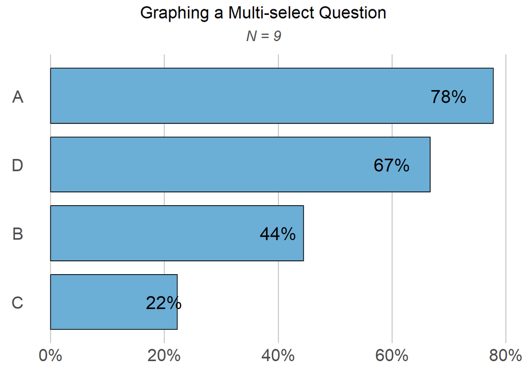

```r
# Notice how in the above output, the "Multi_select_" is automatically truncated off the category (column) names.

x = mc_ftw(data, "Multi_select", return_N = TRUE) # return_n provides the actual number of valid cases, in a list object...
frq_g_simple(x[[1]], "Graphing a Multi-select Question", Custom_N = x[[2]]) # Which we can then utilize for the actual N in this graph...
```

And now for a crosstabulation. With our data here:

```r
# Generate some Gender data...
data = bind_cols(data, tibble(c("F", "M", "M", "M", "M", "F", "M", "F", "F")))
names(data) = c("Multi_select", "Gender")
data
```

| Multi_select | Gender |
| --- | --- |
| A,B,C,D | F |
| A,C | M |
| A,B | M |
| A | M |
| A,D | M |
| B,D | F |
| A,B,D | M |
| D | F |
| A,D | F |

Q: What is the Gender of those who select A’s? I’ve got two options for you.

## Using `mc_ct()`

```r
# Option 1: Use mc_ct. It's very targeted / specific. Which might be good, depending on your use case.
x = mc_ct(data, "Multi_select", "A", "Gender", label_1 = "Type A", label_0 = "Not Type A")
x
```

| Gender | Type A | Not Type A |
| --- | --- | --- |
| Overall | 7 | 2 |
| F (N = 4) | 2 | 2 |
| M (N = 5) | 5 | NA |

```r
# Though obviously the ctable() rendering looks so much better...
ctable(x, Col1Name = "Gender")
```

| Gender | Type A | Not Type A | count | V1 | V2 |
| --- | --- | --- | --- | --- | --- |
| Overall | 0.777777777777778 | 0.222222222222222 | 0 | 10 | 10 |
| F (N = 4) | 0.5 | 0.5 | 4 | 9 | 9 |
| M (N = 5) | 1 |  | 5 | 9 | 9 |

## Using `ct()`

```r
# Option 2: We can also somewhat do this - as in get the same totals - with ct() more generally, but in the present case, this might be less useful. For one, we won't be filtering just for 'A' / 'Not-A': all categories will get returned, so we can't figure out what percentage of each row population answered what way. Secondly, by default, ct()'s N= counts for each row are just row-sums. Because we have a multiple-select question in play here, we need to enable the 'N_adjust' parameter to count cases, rather than total responses, by row.
x = ct(data, "Gender", "Multi_select", N_adjust = T)
x
```

| Gender | A | D | B | C |
| --- | --- | --- | --- | --- |
| Overall | 7 | 6 | 4 | 2 |
| F (N = 4) | 2 | 4 | 2 | 1 |
| M (N = 5) | 5 | 2 | 2 | 1 |

```r
# As you can see, we could try to divide 'A' by the N= values to get the proportion of each category like the other tab's ctable() output. This is inefficient, but just to demonstrate...
x %>%
  select(1:2) %>%
  mutate(N = as.numeric(gsub(".*= (.+)).*", "\\1", Gender))) %>% # Extracting the "N=" value.
  set(1,3,sum(.$N, na.rm=T)) %>% # Cheating, I know, since I'm manually assigning a value here. Maybe I need to re-write this function. :P
  mutate(`Not Type A` = N - A) %>%
  select(-N) %>%
  ctable()
```

| Gender | A | Not Type A | count | V1 | V2 |
| --- | --- | --- | --- | --- | --- |
| Overall | 0.777777777777778 | 0.222222222222222 | 0 | 10 | 10 |
| F (N = 4) | 0.5 | 0.5 | 4 | 9 | 9 |
| M (N = 5) | 1 | 0 | 5 | 9 | 9 |

# 8 Battery Questions & Graphs

Often we use question batteries / matrices in our surveys, where students are asked to agree-disagree or express satisfaction to a number of things at a time using the same scale. The data that comes from Qualtrics then includes all of these questions, with the question text and the response option, as part of the column headers. It’s in that context that we created our `battery_ftw()` and `frq_g_battery()` functions.

For this example, let’s see the multi-selects we were fooling around with above in a graph. To do this, we’ll use the `battery_ftw()` function, which works best given a “Questions” dataframe. Allow me to demonstrate what that might look like by defining one below. Again, this approach is based on the way Qualtrics data tends to come down, and how we’ve attempted to “efficiently” deal with these situations. (We typically create a “Questions” dataframe for reference as a data-cleaning step before we work with the results.)

```r
Questions = data.frame(Q = c("Multi_select_A",
                             "Multi_select_B",
                             "Multi_select_C",
                             "Multi_select_D"),
                       Text = c("Select all that apply. - Cat A",
                                "Select all that apply. - Cat B",
                                "Select all that apply. - Cat C",
                                "Select all that apply. - Cat D"))
Questions
```

| Q | Text |
| --- | --- |
| Multi_select_A | Select all that apply. - Cat A |
| Multi_select_B | Select all that apply. - Cat B |
| Multi_select_C | Select all that apply. - Cat C |
| Multi_select_D | Select all that apply. - Cat D |

```r
# Now back to the data...
MultiCoding(data, "Multi_select")
```

| Multi_select_A | Multi_select_B | Multi_select_C | Multi_select_D |
| --- | --- | --- | --- |
| 1 | 1 | 1 | 1 |
| 1 | 0 | 1 | 0 |
| 1 | 1 | 0 | 0 |
| 1 | 0 | 0 | 0 |
| 1 | 0 | 0 | 1 |
| 0 | 1 | 0 | 1 |
| 1 | 1 | 0 | 1 |
| 0 | 0 | 0 | 1 |
| 1 | 0 | 0 | 1 |

```r
x = MultiCoding(data, "Multi_select")
battery_ftw(x, "Multi_select")
```

| resp | count | 0 | 1 |
| --- | --- | --- | --- |
| Cat A | 9 | 0.2222222 | 0.7777778 |
| Cat B | 9 | 0.5555556 | 0.4444444 |
| Cat C | 9 | 0.7777778 | 0.2222222 |
| Cat D | 9 | 0.3333333 | 0.6666667 |

```r
# Note, there is a Questions_df argument for battery_ftw() - if you don't have a Questions dataframe to reference, set to NULL.
y = battery_ftw(x, "Multi_select") %>%
  rename("Not in Category" = `0`, "In Category" = `1`) # Normally I wouldn't need to rename them, as the values would be the categories in the question; but MultiCoding(), which created my data, just creates dummies, 0/1.
```

And now the graph.

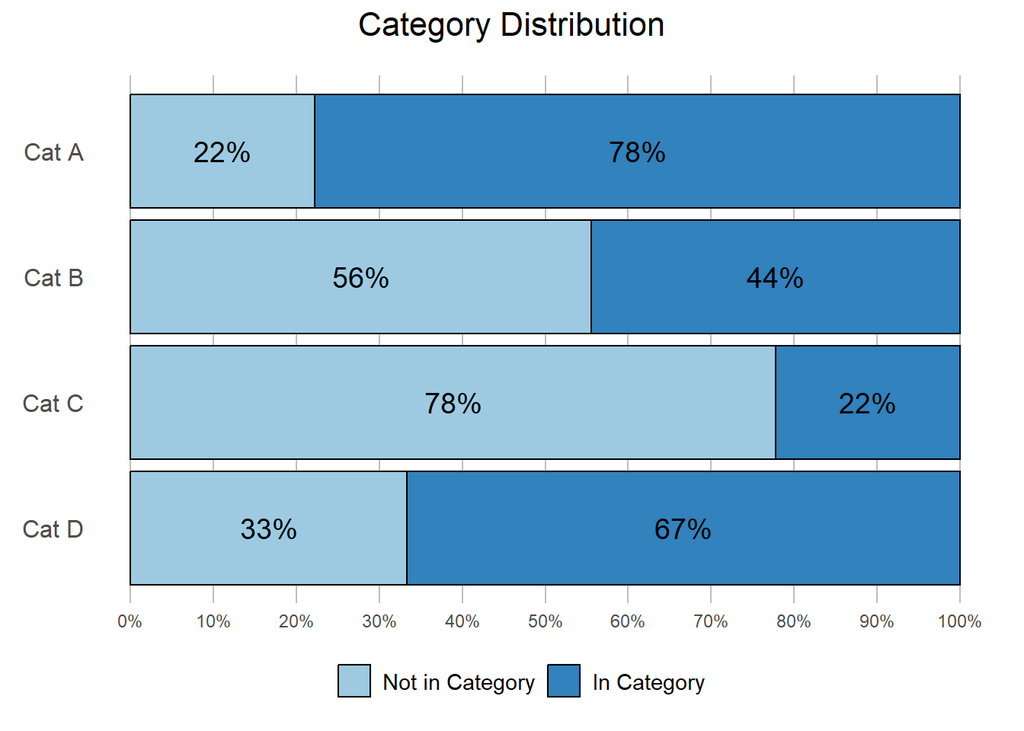

```r
# The last two arguments are purely for aesthetics
frq_g_battery(y, "Category Distribution", N_mode = FALSE, Legend_Rows = 1, Legend_Padding = 30)
```

We can also make these graphs “divergent”, if needed.

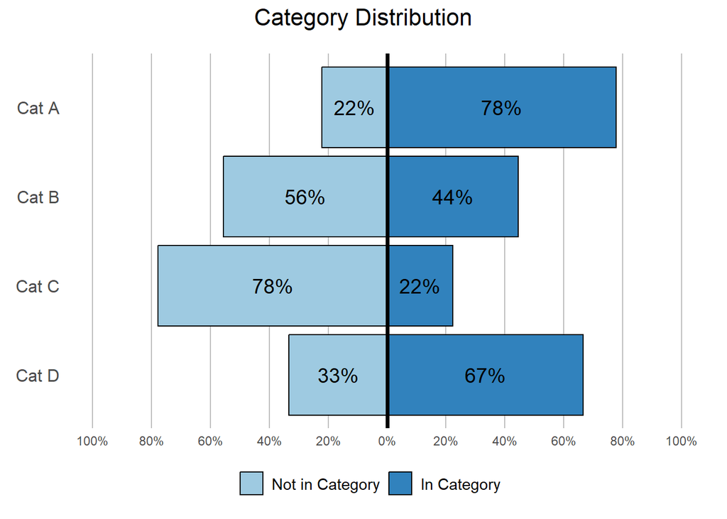

```r
# Note the "divergent" setting, where we define what categories should be on either side of the line.
frq_g_battery(y, "Category Distribution", N_mode = FALSE, Legend_Rows = 1, Legend_Padding = 30, divergent = list(left = c("Not in Category"), right = c("In Category")))
```

# 9 Overlap Graph

Occasionally people want to see a cross-tabulation in a graph format. Here’s one idea for doing that.

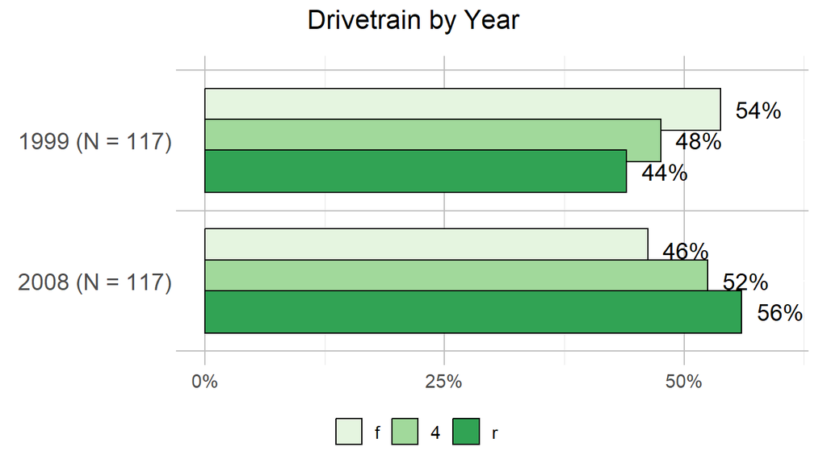

```r
ct(mpg, year, drv)[-1,] %>% # Note: using [-1,] to remove 'overall' summary line
  frq_g_overlap("Drivetrain by Year", spacing = 0.22, bar_width = 0.30, border = T, Fcolour = "Greens", label_font_size = 5)
```

# 10 Histogram

After making a few histograms to summarize course feedback results (meanscores), I randomly decided to build a histogram function. So here’s an example. Let’s look at highway MPG ratings for cars in 2008.

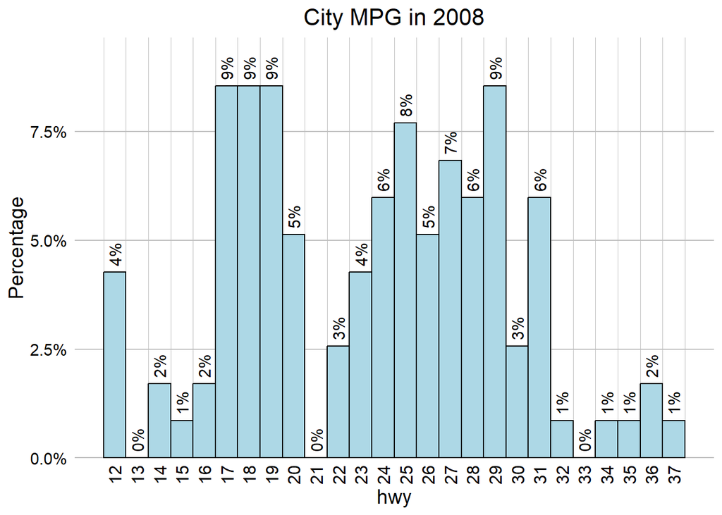

```r
data = filter(mpg, year == 2008)['hwy']
# Obviously needs some work, but it's functional for now.
histo(data, hwy, title = "City MPG in 2008")
```

And by frequency:

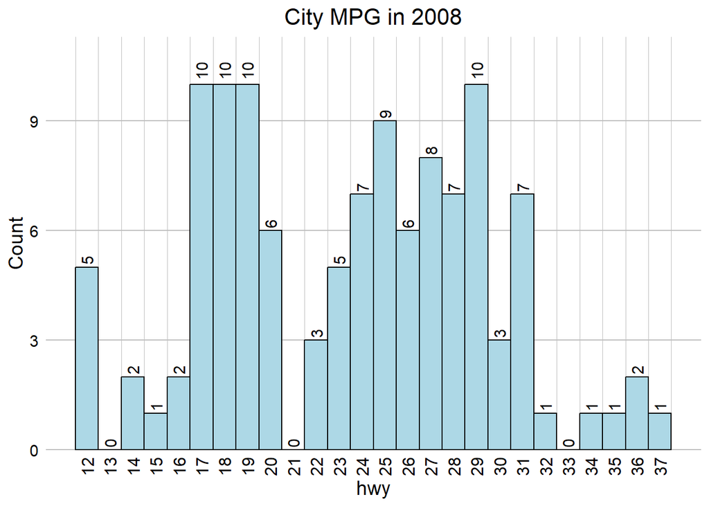

```r
histo(data, hwy, title = "City MPG in 2008", frq = T)
```

*Questions or comments?*  
Email me: fhay (at) conestogac.on.ca